# 13. 多项式回归

如果您的数据点显然不适合线性回归（一条穿过所有数据点的直线），那么多项式回归可能是理想的选择。

多项式回归与线性回归一样，利用变量 x 和 y 之间的关系来找到穿过数据点画直线的最佳方法。

[figure not shown]

- 13.1 代码实现
- 13.2 决定系数
- 13.3 预测未来值
- 13.4 不合适的例子

## 13.1 代码实现

Python 有方法可以找到数据点之间的关系并绘制多项式回归线。我们将向您展示如何使用这些方法，而不是通过数学公式。

在下面的例子中，我们记录了 18 辆经过某个收费站的汽车。

我们记录了汽车的速度以及通过的时间（小时）。

x 轴表示一天中的小时数，y 轴表示速度：

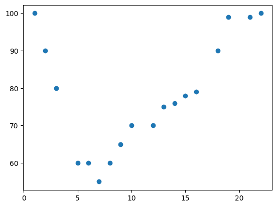

```python
import matplotlib.pyplot as plt
import numpy as np
from sklearn.metrics import r2_score

x = [1,2,3,5,6,7,8,9,10,12,13,14,15,16,18,19,21,22]
y = [100,90,80,60,60,55,60,65,70,70,75,76,78,79,90,99,99,100]

plt.scatter(x, y)
plt.show()
```

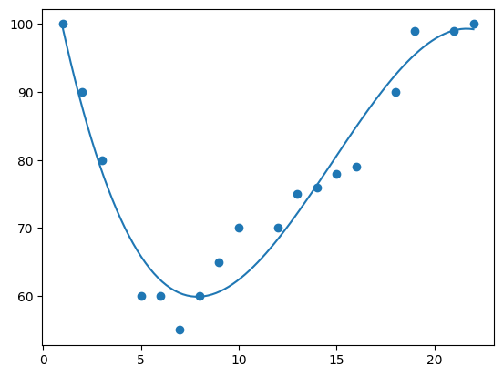

```python
mymodel = np.poly1d(np.polyfit(x, y, 3))

myline = np.linspace(1, 22, 100)

plt.scatter(x, y)
plt.plot(myline, mymodel(myline))
plt.show()
```

## 13.2 决定系数

决定系数，或称判定系数（英语：Coefficient of determination，记为 $R^2$），在统计学中用于度量因变量的变异中可由自变量解释部分所占的比例，以此来判断回归模型的解释力。

因此检查决定系数非常重要，如果 $R^2$ 值过低，多项式回归就无法预测任何事情。

$R^2$ 值的范围从 0 到 1，其中 0 表示没有关系，1 表示 100% 相关。

Python 和 Sklearn 模块将为您计算此值，您所要做的就是向其输入 x 和 y 数组：

```python
print(r2_score(y, mymodel(x)))
```

```
0.9432150416451026
```

> **注**：结果 $R^2 = 0.94$ 表明关系非常好，我们可以在未来的预测中使用该多项式回归。

## 13.3 预测未来值

现在我们可以使用收集到的信息来预测未来值。

示例：让我们尝试预测在 17:00 左右经过收费站的汽车的速度：

为此，我们需要与上述示例相同的 mymodel 数组：

```
88.87331269698001
```

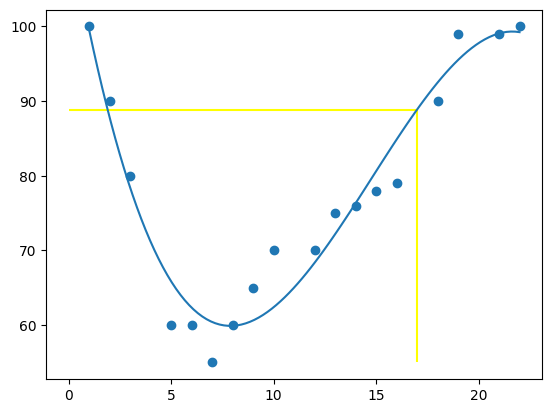

```python
speed = mymodel(17)
print(speed)

plt.vlines(x=17, ymin=55, ymax=speed, colors = 'yellow')
plt.hlines(y=speed, xmin=0, xmax=17, colors = 'yellow')
plt.scatter(x, y)
plt.plot(myline, mymodel(myline))
plt.show()
```

## 13.4 不合适的例子

让我们举一个例子，用多项式回归不是预测未来值的最佳方法。

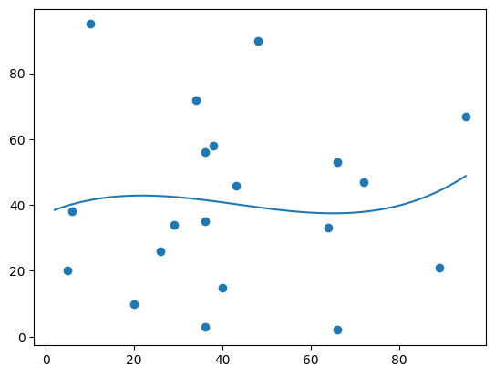

```python
x = [89,43,36,36,95,10,66,34,38,20,26,29,48,64,6,5,36,66,72,40]
y = [21,46,3,35,67,95,53,72,58,10,26,34,90,33,38,20,56,2,47,15]

mymodel = np.poly1d(np.polyfit(x, y, 3))

myline = np.linspace(2, 95, 100)

plt.scatter(x, y)
plt.plot(myline, mymodel(myline))
plt.show()
```

您应该会得到一个非常低的 $R^2$ 值。

> **结果**：0.00995 表示关系非常糟糕，告诉我们该数据集不适合多项式回归。

```python
print(r2_score(y, mymodel(x)))
```

```
0.009952707566680652
```